### Internship TASK_Business Analysis

# Telecom_Customer_Churn_Data Analysis

## Tasks 1: Understand the Dataset

```python
import pandas as pd

# Load the dataset (update the filename if needed)
df = pd.read_csv("C:/Users/Sushma Banu/Downloads/Telco_Customer_Churn_Dataset  (3).csv")  # Replace with your file path if necessary
```

```python
df.head(10)
```

|  | customerID | gender | SeniorCitizen | Partner | Dependents | tenure | PhoneService | MultipleLines | InternetService | OnlineSecurity | ... | DeviceProtection | TechSupport | StreamingTV | StreamingMovies | Contract | PaperlessBilling | PaymentMethod | MonthlyCharges | TotalCharges | Churn |
| --- | --- | --- | --- | --- | --- | --- | --- | --- | --- | --- | --- | --- | --- | --- | --- | --- | --- | --- | --- | --- | --- |
| 0 | 7590-VHVEG | Female | 0 | Yes | No | 1 | No | No phone service | DSL | No | ... | No | No | No | No | Month-to-month | Yes | Electronic check | 29.85 | 29.85 | No |
| 1 | 5575-GNVDE | Male | 0 | No | No | 34 | Yes | No | DSL | Yes | ... | Yes | No | No | No | One year | No | Mailed check | 56.95 | 1889.5 | No |
| 2 | 3668-QPYBK | Male | 0 | No | No | 2 | Yes | No | DSL | Yes | ... | No | No | No | No | Month-to-month | Yes | Mailed check | 53.85 | 108.15 | Yes |
| 3 | 7795-CFOCW | Male | 0 | No | No | 45 | No | No phone service | DSL | Yes | ... | Yes | Yes | No | No | One year | No | Bank transfer (automatic) | 42.30 | 1840.75 | No |
| 4 | 9237-HQITU | Female | 0 | No | No | 2 | Yes | No | Fiber optic | No | ... | No | No | No | No | Month-to-month | Yes | Electronic check | 70.70 | 151.65 | Yes |
| 5 | 9305-CDSKC | Female | 0 | No | No | 8 | Yes | Yes | Fiber optic | No | ... | Yes | No | Yes | Yes | Month-to-month | Yes | Electronic check | 99.65 | 820.5 | Yes |
| 6 | 1452-KIOVK | Male | 0 | No | Yes | 22 | Yes | Yes | Fiber optic | No | ... | No | No | Yes | No | Month-to-month | Yes | Credit card (automatic) | 89.10 | 1949.4 | No |
| 7 | 6713-OKOMC | Female | 0 | No | No | 10 | No | No phone service | DSL | Yes | ... | No | No | No | No | Month-to-month | No | Mailed check | 29.75 | 301.9 | No |
| 8 | 7892-POOKP | Female | 0 | Yes | No | 28 | Yes | Yes | Fiber optic | No | ... | Yes | Yes | Yes | Yes | Month-to-month | Yes | Electronic check | 104.80 | 3046.05 | Yes |
| 9 | 6388-TABGU | Male | 0 | No | Yes | 62 | Yes | No | DSL | Yes | ... | No | No | No | No | One year | No | Bank transfer (automatic) | 56.15 | 3487.95 | No |

10 rows × 21 columns

```python
df.dtypes
```

```
customerID           object
gender               object
SeniorCitizen         int64
Partner              object
Dependents           object
tenure                int64
PhoneService         object
MultipleLines        object
InternetService      object
OnlineSecurity       object
OnlineBackup         object
DeviceProtection     object
TechSupport          object
StreamingTV          object
StreamingMovies      object
Contract             object
PaperlessBilling     object
PaymentMethod        object
MonthlyCharges      float64
TotalCharges         object
Churn                object
dtype: object
```

```python
df.isnull().sum()
```

```
customerID          0
gender              0
SeniorCitizen       0
Partner             0
Dependents          0
tenure              0
PhoneService        0
MultipleLines       0
InternetService     0
OnlineSecurity      0
OnlineBackup        0
DeviceProtection    0
TechSupport         0
StreamingTV         0
StreamingMovies     0
Contract            0
PaperlessBilling    0
PaymentMethod       0
MonthlyCharges      0
TotalCharges        0
Churn               0
dtype: int64
```

## Tasks 2: Data Cleaning ( Ensure the dataset is clean for analysis.)

```python
# Convert 'TotalCharges' to numeric (coerce invalid values to NaN)
df['TotalCharges'] = pd.to_numeric(df['TotalCharges'], errors='coerce')

# Check again for missing values
print("Missing values per column:")
print(df.isnull().sum())

# Option 1: Fill missing values in 'TotalCharges' with the median
df['TotalCharges'].fillna(df['TotalCharges'].median(), inplace=True)
```

```
Missing values per column:
customerID           0
gender               0
SeniorCitizen        0
Partner              0
Dependents           0
tenure               0
PhoneService         0
MultipleLines        0
InternetService      0
OnlineSecurity       0
OnlineBackup         0
DeviceProtection     0
TechSupport          0
StreamingTV          0
StreamingMovies      0
Contract             0
PaperlessBilling     0
PaymentMethod        0
MonthlyCharges       0
TotalCharges        11
Churn                0
dtype: int64
```

[output not shown]

```python
# Rename columns to lowercase and replace spaces with underscores
df.columns = df.columns.str.lower().str.replace(' ', '_')
```

## Tasks 3: Exploratory Data Analysis (EDA)

```python
# Summary statistics for numerical columns
df.describe()
```

|  | seniorcitizen | tenure | monthlycharges | totalcharges |
| --- | --- | --- | --- | --- |
| count | 7043.000000 | 7043.000000 | 7043.000000 | 7043.000000 |
| mean | 0.162147 | 32.371149 | 64.761692 | 2281.916928 |
| std | 0.368612 | 24.559481 | 30.090047 | 2265.270398 |
| min | 0.000000 | 0.000000 | 18.250000 | 18.800000 |
| 25% | 0.000000 | 9.000000 | 35.500000 | 402.225000 |
| 50% | 0.000000 | 29.000000 | 70.350000 | 1397.475000 |
| 75% | 0.000000 | 55.000000 | 89.850000 | 3786.600000 |
| max | 1.000000 | 72.000000 | 118.750000 | 8684.800000 |

```python
# Summary including categorical variables
df.describe(include='all')
```

|  | customerid | gender | seniorcitizen | partner | dependents | tenure | phoneservice | multiplelines | internetservice | onlinesecurity | ... | deviceprotection | techsupport | streamingtv | streamingmovies | contract | paperlessbilling | paymentmethod | monthlycharges | totalcharges | churn |
| --- | --- | --- | --- | --- | --- | --- | --- | --- | --- | --- | --- | --- | --- | --- | --- | --- | --- | --- | --- | --- | --- |
| count | 7043 | 7043 | 7043.000000 | 7043 | 7043 | 7043.000000 | 7043 | 7043 | 7043 | 7043 | ... | 7043 | 7043 | 7043 | 7043 | 7043 | 7043 | 7043 | 7043.000000 | 7043.000000 | 7043 |
| unique | 7043 | 2 | NaN | 2 | 2 | NaN | 2 | 3 | 3 | 3 | ... | 3 | 3 | 3 | 3 | 3 | 2 | 4 | NaN | NaN | 2 |
| top | 7590-VHVEG | Male | NaN | No | No | NaN | Yes | No | Fiber optic | No | ... | No | No | No | No | Month-to-month | Yes | Electronic check | NaN | NaN | No |
| freq | 1 | 3555 | NaN | 3641 | 4933 | NaN | 6361 | 3390 | 3096 | 3498 | ... | 3095 | 3473 | 2810 | 2785 | 3875 | 4171 | 2365 | NaN | NaN | 5174 |
| mean | NaN | NaN | 0.162147 | NaN | NaN | 32.371149 | NaN | NaN | NaN | NaN | ... | NaN | NaN | NaN | NaN | NaN | NaN | NaN | 64.761692 | 2281.916928 | NaN |
| std | NaN | NaN | 0.368612 | NaN | NaN | 24.559481 | NaN | NaN | NaN | NaN | ... | NaN | NaN | NaN | NaN | NaN | NaN | NaN | 30.090047 | 2265.270398 | NaN |
| min | NaN | NaN | 0.000000 | NaN | NaN | 0.000000 | NaN | NaN | NaN | NaN | ... | NaN | NaN | NaN | NaN | NaN | NaN | NaN | 18.250000 | 18.800000 | NaN |
| 25% | NaN | NaN | 0.000000 | NaN | NaN | 9.000000 | NaN | NaN | NaN | NaN | ... | NaN | NaN | NaN | NaN | NaN | NaN | NaN | 35.500000 | 402.225000 | NaN |
| 50% | NaN | NaN | 0.000000 | NaN | NaN | 29.000000 | NaN | NaN | NaN | NaN | ... | NaN | NaN | NaN | NaN | NaN | NaN | NaN | 70.350000 | 1397.475000 | NaN |
| 75% | NaN | NaN | 0.000000 | NaN | NaN | 55.000000 | NaN | NaN | NaN | NaN | ... | NaN | NaN | NaN | NaN | NaN | NaN | NaN | 89.850000 | 3786.600000 | NaN |
| max | NaN | NaN | 1.000000 | NaN | NaN | 72.000000 | NaN | NaN | NaN | NaN | ... | NaN | NaN | NaN | NaN | NaN | NaN | NaN | 118.750000 | 8684.800000 | NaN |

11 rows × 21 columns

```python
# Mean of numerical columns
df.mean(numeric_only=True)
```

```
seniorcitizen        0.162147
tenure              32.371149
monthlycharges      64.761692
totalcharges      2281.916928
dtype: float64
```

```python
# Median of numerical columns
df.median(numeric_only=True)
```

```
seniorcitizen        0.000
tenure              29.000
monthlycharges      70.350
totalcharges      1397.475
dtype: float64
```

```python
# Mode for each column
df.mode().iloc[0]
```

```
customerid                0002-ORFBO
gender                          Male
seniorcitizen                    0.0
partner                           No
dependents                        No
tenure                           1.0
phoneservice                     Yes
multiplelines                     No
internetservice          Fiber optic
onlinesecurity                    No
onlinebackup                      No
deviceprotection                  No
techsupport                       No
streamingtv                       No
streamingmovies                   No
contract              Month-to-month
paperlessbilling                 Yes
paymentmethod       Electronic check
monthlycharges                 20.05
totalcharges                    20.2
churn                             No
Name: 0, dtype: object
```

# Visualize Numerical Columns

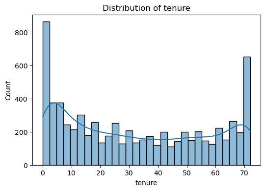

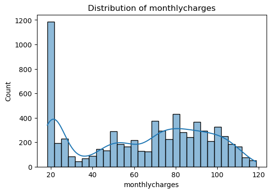

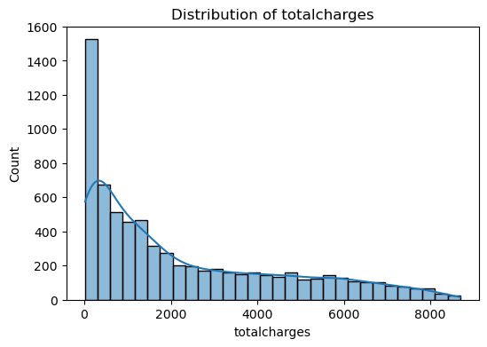

```python
import matplotlib.pyplot as plt
import seaborn as sns

# Plot histograms for numerical columns
num_cols = ['tenure', 'monthlycharges', 'totalcharges']

for col in num_cols:
    plt.figure(figsize=(6,4))
    sns.histplot(df[col], kde=True, bins=30)
    plt.title(f'Distribution of {col}')
    plt.xlabel(col)
    plt.ylabel('Count')
    plt.show()
```

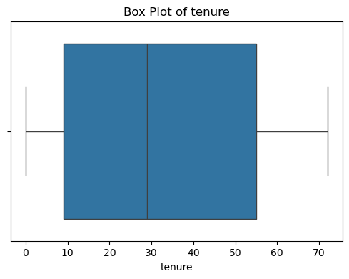

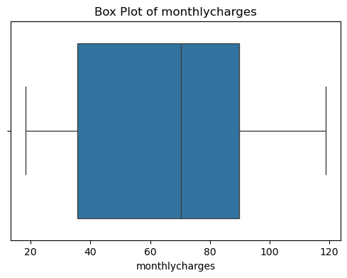

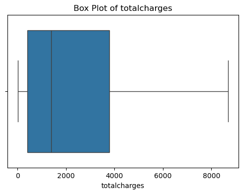

```python
# Boxplots to detect outliers
for col in num_cols:
    plt.figure(figsize=(6,4))
    sns.boxplot(x=df[col])
    plt.title(f'Box Plot of {col}')
    plt.xlabel(col)
    plt.show()
```

```python
#Analyze Churn Rates
# Count of churned vs non-churned
print(df['churn'].value_counts())

# Proportion of churned vs non-churned
print(df['churn'].value_counts(normalize=True))
```

```
churn
No     5174
Yes    1869
Name: count, dtype: int64
churn
No     0.73463
Yes    0.26537
Name: proportion, dtype: float64
```

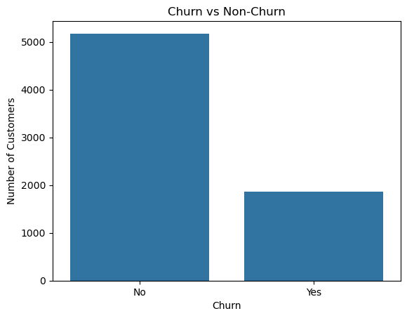

```python
#Bar Plot for Churn Distribution
sns.countplot(x='churn', data=df)
plt.title("Churn vs Non-Churn")
plt.xlabel("Churn")
plt.ylabel("Number of Customers")
plt.show()
```

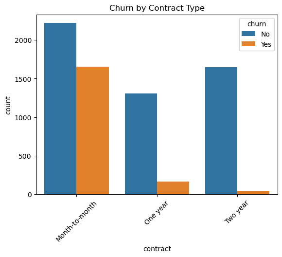

```python
#Optional: Churn by Contract Type
sns.countplot(x='contract', hue='churn', data=df)
plt.title("Churn by Contract Type")
plt.xticks(rotation=45)
plt.show()
```

## Tasks 4: Customer Segmentation Visualization

```python
# Visualize Customer Distribution by Tenure Using Pie/Donut Chart
# Create tenure categories
bins = [0, 12, 36, df['tenure'].max()]
labels = ['0-12 months', '13-36 months', '37+ months']
df['tenure_group'] = pd.cut(df['tenure'], bins=bins, labels=labels, right=True)
```

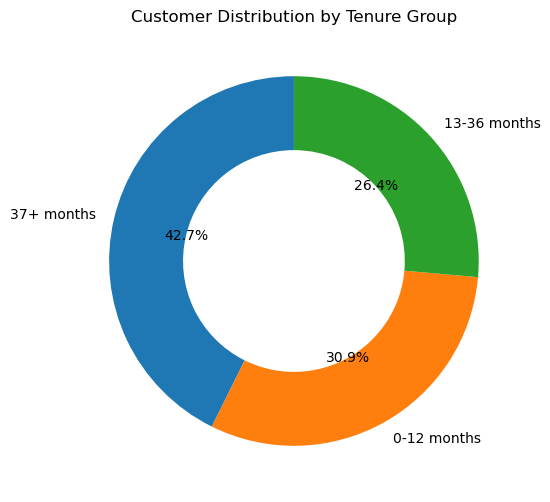

```python
import matplotlib.pyplot as plt

# Count of customers in each tenure group
tenure_counts = df['tenure_group'].value_counts()

# Donut chart
plt.figure(figsize=(6,6))
plt.pie(tenure_counts, labels=tenure_counts.index, autopct='%1.1f%%', startangle=90, wedgeprops=dict(width=0.4))
plt.title('Customer Distribution by Tenure Group')
plt.show()
```

```python
#Clustered Bar Chart: Average Monthly Charges by Tenure Group & Churn
# Group by tenure group and churn
avg_charges = df.groupby(['tenure_group', 'churn'])['monthlycharges'].mean().reset_index()
```

```
C:\Users\Sushma Banu\AppData\Local\Temp\ipykernel_25128\2323516394.py:3: FutureWarning: The default of observed=False is deprecated and will be changed to True in a future version of pandas. Pass observed=False to retain current behavior or observed=True to adopt the future default and silence this …
  avg_charges = df.groupby(['tenure_group', 'churn'])['monthlycharges'].mean().reset_index()
```

[figure not shown]

```python
import seaborn as sns

plt.figure(figsize=(8,6))
sns.barplot(x='tenure_group', y='monthlycharges', hue='churn', data=avg_charges)

# Add annotations
for index, row in avg_charges.iterrows():
    plt.text(index % 3 - 0.2 + 0.15 * (row['churn'] == 'Yes'),  # X position
             row['monthlycharges'] + 1,                        # Y position
             round(row['monthlycharges'], 1),                  # Text
             color='black',
             ha="center")

plt.title('Average Monthly Charges by Tenure Group and Churn')
plt.ylabel('Average Monthly Charges')
plt.xlabel('Tenure Group')
plt.show()
```

## Tasks 5: Advanced Analysis

```python
#Group Customers by Tenure (Binned) → Compute Stats for Charges and Churn
# Already created earlier
bins = [0, 12, 36, df['tenure'].max()]
labels = ['0-12 months', '13-36 months', '37+ months']
df['tenure_group'] = pd.cut(df['tenure'], bins=bins, labels=labels, right=True)
```

```python
#Grouped Stats by Tenure Group
# Compute mean monthly charges, total charges, churn rate
tenure_stats = df.groupby('tenure_group').agg(
    avg_monthly_charges=('monthlycharges', 'mean'),
    avg_total_charges=('totalcharges', 'mean'),
    churn_rate=('churn', lambda x: (x == 'Yes').mean() * 100),
    count=('churn', 'count')
).reset_index()

tenure_stats
```

```
C:\Users\Sushma Banu\AppData\Local\Temp\ipykernel_25128\4275856812.py:3: FutureWarning: The default of observed=False is deprecated and will be changed to True in a future version of pandas. Pass observed=False to retain current behavior or observed=True to adopt the future default and silence this …
  tenure_stats = df.groupby('tenure_group').agg(
```

|  | tenure_group | avg_monthly_charges | avg_total_charges | churn_rate | count |
| --- | --- | --- | --- | --- | --- |
| 0 | 0-12 months | 56.172023 | 276.621563 | 47.678161 | 2175 |
| 1 | 13-36 months | 63.248195 | 1513.541756 | 25.538793 | 1856 |
| 2 | 37+ months | 72.008730 | 4213.723192 | 11.929357 | 3001 |

Analyze Churn Rates by Demographics

```
churn          No        Yes
gender
Female  73.079128  26.920872
Male    73.839662  26.160338
```

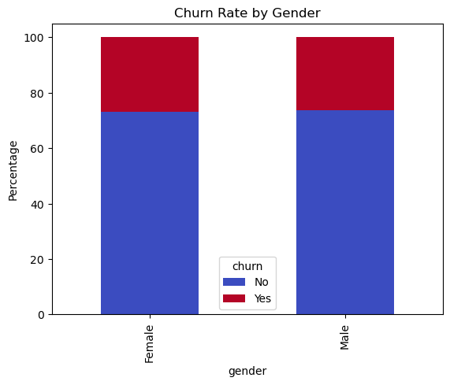

```python
churn_by_gender = df.groupby('gender')['churn'].value_counts(normalize=True).unstack() * 100
print(churn_by_gender)

# Bar plot
churn_by_gender.plot(kind='bar', stacked=True, colormap='coolwarm')
plt.title('Churn Rate by Gender')
plt.ylabel('Percentage')
plt.show()
```

```
churn                 No        Yes
seniorcitizen
0              76.393832  23.606168
1              58.318739  41.681261
```

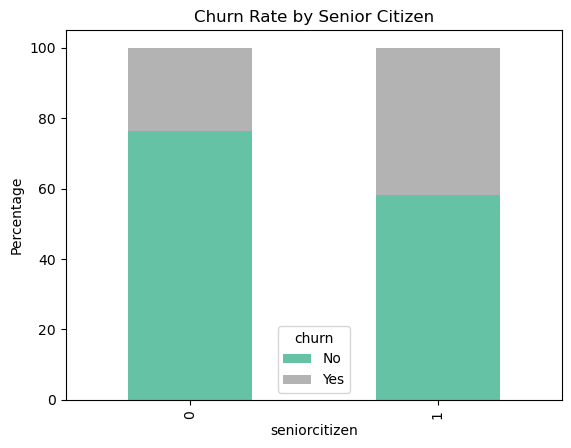

```python
churn_by_senior = df.groupby('seniorcitizen')['churn'].value_counts(normalize=True).unstack() * 100
print(churn_by_senior)

# Bar plot
churn_by_senior.plot(kind='bar', stacked=True, colormap='Set2')
plt.title('Churn Rate by Senior Citizen')
plt.ylabel('Percentage')
plt.show()
```

Analyze Churn by Payment Method and Contract Type

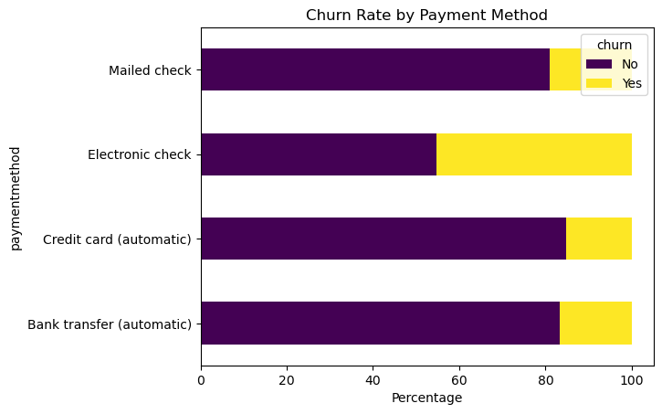

```python
churn_by_payment = df.groupby('paymentmethod')['churn'].value_counts(normalize=True).unstack() * 100
churn_by_payment.plot(kind='barh', stacked=True, colormap='viridis')
plt.title('Churn Rate by Payment Method')
plt.xlabel('Percentage')
plt.show()
```

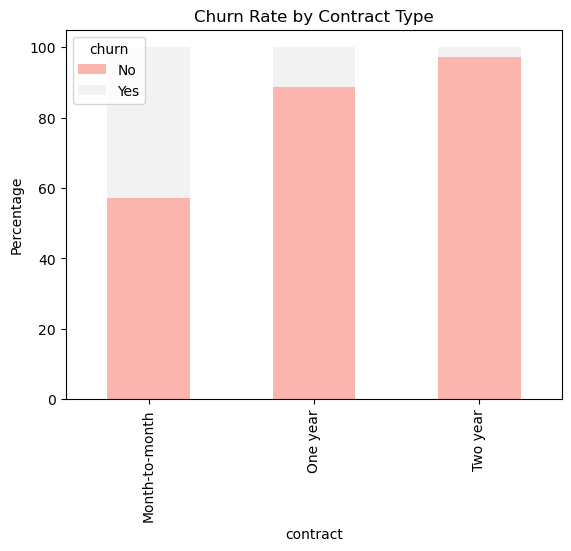

```python
churn_by_contract = df.groupby('contract')['churn'].value_counts(normalize=True).unstack() * 100
churn_by_contract.plot(kind='bar', stacked=True, colormap='Pastel1')
plt.title('Churn Rate by Contract Type')
plt.ylabel('Percentage')
plt.show()
```

Lifecycle or Tenure Trends (Line Plot for Churn by Tenure)

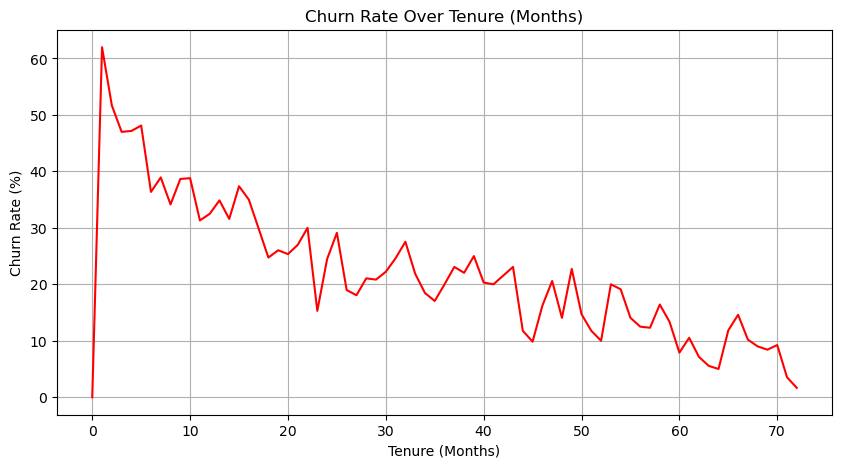

```python
# Churn rate by individual tenure (0-72 months)
churn_by_tenure = df.groupby('tenure')['churn'].apply(lambda x: (x == 'Yes').mean() * 100)

plt.figure(figsize=(10,5))
churn_by_tenure.plot(kind='line', color='red')
plt.title("Churn Rate Over Tenure (Months)")
plt.xlabel("Tenure (Months)")
plt.ylabel("Churn Rate (%)")
plt.grid(True)
plt.show()
```

### ✅ Key Findings – Customer Churn Analysis

Customers with 0–12 months tenure have the highest churn rate.

Churn rate decreases as tenure increases (more loyal long-term customers).

Churned customers have higher monthly charges but lower total charges (left early).

Senior citizens churn more than younger customers.

Month-to-month contracts have the highest churn; 1-year and 2-year contracts have much lower churn.

Customers paying via electronic check churn more than those using auto-payment methods.

## Skills Gained from Churn Analysis Project

Data Cleaning & Preprocessing

Handling missing values

Standardizing column names

Exploratory Data Analysis (EDA)

Generating summary statistics (mean, median, mode)

Understanding data distributions using histograms and box plots

Data Visualization

Pie and donut charts for customer segmentation

Bar charts and line graphs for trend analysis

Annotated and comparative visualizations using Seaborn & Matplotlib

Categorical Analysis

Analyzing churn by gender, senior citizen status, contract type, and payment method

Customer Segmentation

Grouping by tenure ranges to study churn and charges

Churn Rate Analysis

Identifying patterns and risks in customer lifecycle stages

Insight Generation & Business Recommendation